# Optimal Treatment Analysis

## Outcome Variable

**Outcome Variable:** ever_stunted

## Predictor Variables

**Intervention Variable:** gagebrth

**Adjustment Set:**

- arm
- sex
- W_mage
- W_fage
- meducyrs
- feducyrs
- single
- brthmon
- W_parity
- delta_W_mage
- delta_W_fage
- delta_meducyrs
- delta_feducyrs
- delta_single
- delta_brthmon
- delta_W_parity

## Stratifying Variables

The analysis was stratified on these variable(s):

- agecat
- studyid
- country

## Data Summary

| agecat | studyid | country | gagebrth | ever_stunted | n_cell | n |
| --- | --- | --- | --- | --- | --- | --- |
| 0-24 months (no birth st.) | ki1000108-CMC-V-BCS-2002 | INDIA | Full or late term | 0 | 18 | 278 |
| 0-24 months (no birth st.) | ki1000108-CMC-V-BCS-2002 | INDIA | Full or late term | 1 | 164 | 278 |
| 0-24 months (no birth st.) | ki1000108-CMC-V-BCS-2002 | INDIA | Preterm | 0 | 3 | 278 |
| 0-24 months (no birth st.) | ki1000108-CMC-V-BCS-2002 | INDIA | Preterm | 1 | 30 | 278 |
| 0-24 months (no birth st.) | ki1000108-CMC-V-BCS-2002 | INDIA | Early term | 0 | 7 | 278 |
| 0-24 months (no birth st.) | ki1000108-CMC-V-BCS-2002 | INDIA | Early term | 1 | 56 | 278 |
| 0-24 months (no birth st.) | ki1000108-IRC | INDIA | Full or late term | 0 | 95 | 341 |
| 0-24 months (no birth st.) | ki1000108-IRC | INDIA | Full or late term | 1 | 126 | 341 |
| 0-24 months (no birth st.) | ki1000108-IRC | INDIA | Preterm | 0 | 9 | 341 |
| 0-24 months (no birth st.) | ki1000108-IRC | INDIA | Preterm | 1 | 23 | 341 |
| 0-24 months (no birth st.) | ki1000108-IRC | INDIA | Early term | 0 | 34 | 341 |
| 0-24 months (no birth st.) | ki1000108-IRC | INDIA | Early term | 1 | 54 | 341 |
| 0-24 months (no birth st.) | ki1000109-EE | PAKISTAN | Full or late term | 0 | 3 | 249 |
| 0-24 months (no birth st.) | ki1000109-EE | PAKISTAN | Full or late term | 1 | 15 | 249 |
| 0-24 months (no birth st.) | ki1000109-EE | PAKISTAN | Preterm | 0 | 14 | 249 |
| 0-24 months (no birth st.) | ki1000109-EE | PAKISTAN | Preterm | 1 | 146 | 249 |
| 0-24 months (no birth st.) | ki1000109-EE | PAKISTAN | Early term | 0 | 16 | 249 |
| 0-24 months (no birth st.) | ki1000109-EE | PAKISTAN | Early term | 1 | 55 | 249 |
| 0-24 months (no birth st.) | ki1000304b-SAS-CompFeed | INDIA | Full or late term | 0 | 8 | 1081 |
| 0-24 months (no birth st.) | ki1000304b-SAS-CompFeed | INDIA | Full or late term | 1 | 16 | 1081 |
| 0-24 months (no birth st.) | ki1000304b-SAS-CompFeed | INDIA | Preterm | 0 | 422 | 1081 |
| 0-24 months (no birth st.) | ki1000304b-SAS-CompFeed | INDIA | Preterm | 1 | 550 | 1081 |
| 0-24 months (no birth st.) | ki1000304b-SAS-CompFeed | INDIA | Early term | 0 | 35 | 1081 |
| 0-24 months (no birth st.) | ki1000304b-SAS-CompFeed | INDIA | Early term | 1 | 50 | 1081 |
| 0-24 months (no birth st.) | ki1017093c-NIH-Crypto | BANGLADESH | Full or late term | 0 | 105 | 653 |
| 0-24 months (no birth st.) | ki1017093c-NIH-Crypto | BANGLADESH | Full or late term | 1 | 51 | 653 |
| 0-24 months (no birth st.) | ki1017093c-NIH-Crypto | BANGLADESH | Preterm | 0 | 110 | 653 |
| 0-24 months (no birth st.) | ki1017093c-NIH-Crypto | BANGLADESH | Preterm | 1 | 89 | 653 |
| 0-24 months (no birth st.) | ki1017093c-NIH-Crypto | BANGLADESH | Early term | 0 | 181 | 653 |
| 0-24 months (no birth st.) | ki1017093c-NIH-Crypto | BANGLADESH | Early term | 1 | 117 | 653 |

[output cut: 186 more lines]

The following strata were considered:

- agecat: 0-24 months (no birth st.), studyid: ki1000108-CMC-V-BCS-2002, country: INDIA
- agecat: 0-24 months (no birth st.), studyid: ki1000108-IRC, country: INDIA
- agecat: 0-24 months (no birth st.), studyid: ki1000109-EE, country: PAKISTAN
- agecat: 0-24 months (no birth st.), studyid: ki1000304b-SAS-CompFeed, country: INDIA
- agecat: 0-24 months (no birth st.), studyid: ki1017093c-NIH-Crypto, country: BANGLADESH
- agecat: 0-24 months (no birth st.), studyid: ki1066203-TanzaniaChild2, country: TANZANIA, UNITED REPUBLIC OF
- agecat: 0-24 months (no birth st.), studyid: ki1101329-Keneba, country: GAMBIA
- agecat: 0-24 months (no birth st.), studyid: ki1119695-PROBIT, country: BELARUS
- agecat: 0-24 months (no birth st.), studyid: ki1135781-COHORTS, country: GUATEMALA
- agecat: 0-24 months (no birth st.), studyid: ki1135781-COHORTS, country: INDIA
- agecat: 0-24 months (no birth st.), studyid: ki1135781-COHORTS, country: PHILIPPINES
- agecat: 0-24 months (no birth st.), studyid: kiGH5241-JiVitA-3, country: BANGLADESH
- agecat: 0-6 months (no birth st.), studyid: ki1000108-CMC-V-BCS-2002, country: INDIA
- agecat: 0-6 months (no birth st.), studyid: ki1000108-IRC, country: INDIA
- agecat: 0-6 months (no birth st.), studyid: ki1000109-EE, country: PAKISTAN
- agecat: 0-6 months (no birth st.), studyid: ki1000304b-SAS-CompFeed, country: INDIA
- agecat: 0-6 months (no birth st.), studyid: ki1017093c-NIH-Crypto, country: BANGLADESH
- agecat: 0-6 months (no birth st.), studyid: ki1066203-TanzaniaChild2, country: TANZANIA, UNITED REPUBLIC OF
- agecat: 0-6 months (no birth st.), studyid: ki1101329-Keneba, country: GAMBIA
- agecat: 0-6 months (no birth st.), studyid: ki1119695-PROBIT, country: BELARUS
- agecat: 0-6 months (no birth st.), studyid: ki1135781-COHORTS, country: GUATEMALA
- agecat: 0-6 months (no birth st.), studyid: ki1135781-COHORTS, country: INDIA
- agecat: 0-6 months (no birth st.), studyid: ki1135781-COHORTS, country: PHILIPPINES
- agecat: 0-6 months (no birth st.), studyid: kiGH5241-JiVitA-3, country: BANGLADESH
- agecat: 6-24 months, studyid: ki1000108-CMC-V-BCS-2002, country: INDIA
- agecat: 6-24 months, studyid: ki1000108-IRC, country: INDIA
- agecat: 6-24 months, studyid: ki1000109-EE, country: PAKISTAN
- agecat: 6-24 months, studyid: ki1000304b-SAS-CompFeed, country: INDIA
- agecat: 6-24 months, studyid: ki1017093c-NIH-Crypto, country: BANGLADESH
- agecat: 6-24 months, studyid: ki1066203-TanzaniaChild2, country: TANZANIA, UNITED REPUBLIC OF
- agecat: 6-24 months, studyid: ki1101329-Keneba, country: GAMBIA
- agecat: 6-24 months, studyid: ki1119695-PROBIT, country: BELARUS
- agecat: 6-24 months, studyid: ki1135781-COHORTS, country: GUATEMALA
- agecat: 6-24 months, studyid: ki1135781-COHORTS, country: INDIA
- agecat: 6-24 months, studyid: ki1135781-COHORTS, country: PHILIPPINES
- agecat: 6-24 months, studyid: kiGH5241-JiVitA-3, country: BANGLADESH

### Dropped Strata

Some strata were dropped due to rare outcomes:

- agecat: 0-24 months (no birth st.), studyid: ki1000108-CMC-V-BCS-2002, country: INDIA
- agecat: 0-24 months (no birth st.), studyid: ki1000109-EE, country: PAKISTAN
- agecat: 0-6 months (no birth st.), studyid: ki1000304b-SAS-CompFeed, country: INDIA
- agecat: 6-24 months, studyid: ki1000108-CMC-V-BCS-2002, country: INDIA
- agecat: 6-24 months, studyid: ki1000109-EE, country: PAKISTAN

## Methods Detail

We’re interested in the causal parameters $E[Y_a]$ for all values of $a \in \mathcal{A}$. These parameters represent the mean outcome if, possibly contrary to fact, we intervened to set all units to have $A=a$. Under the randomization and positivity assumptions, these are identified by the statistical parameters $\psi_a=E_W[E_{Y|A,W}(Y|A=a,W)]$. In addition, we’re interested in the mean of $Y$, $E[Y]$ under no intervention (the observed mean). We will estimate these parameters by using SuperLearner to fit the relevant likelihood factors – $E_{Y|A,W}(Y|A=a,W)$ and $p(A=a|W)$, and then updating our likelihood fit using a joint TMLE.

For unadjusted analyses ($W=\{\}$), initial likelihoods were estimated using Lrnr_glm to estimate the simple $E(Y|A)$ and Lrnr_mean to estimate $p(A)$. For adjusted analyses, a small library containing Lrnr_glmnet, Lrnr_xgboost, and Lrnr_mean was used.

Having estimated these parameters, we will then use the delta method to estimate relative risks and attributable risks relative to a prespecified baseline level of $A$.

# Results Detail

## Results Plots

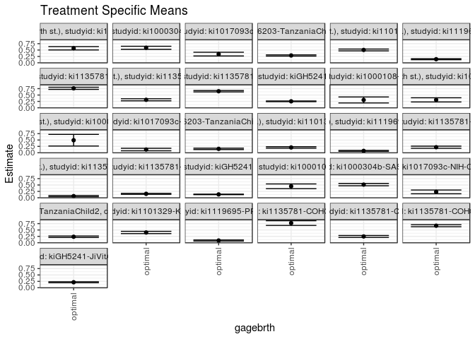

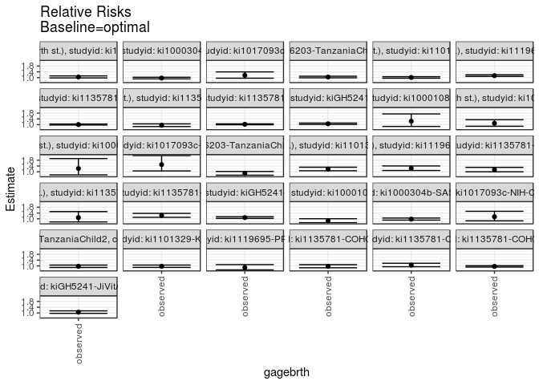

## Results Table

### Parameter: TSM

| agecat | studyid | country | intervention_level | baseline_level | estimate | ci_lower | ci_upper |
| --- | --- | --- | --- | --- | --- | --- | --- |
| 0-24 months (no birth st.) | ki1000108-IRC | INDIA | optimal | NA | 0.5701335 | 0.5045631 | 0.6357040 |
| 0-24 months (no birth st.) | ki1000304b-SAS-CompFeed | INDIA | optimal | NA | 0.5890812 | 0.5293552 | 0.6488073 |
| 0-24 months (no birth st.) | ki1017093c-NIH-Crypto | BANGLADESH | optimal | NA | 0.3402233 | 0.2668971 | 0.4135495 |
| 0-24 months (no birth st.) | ki1066203-TanzaniaChild2 | TANZANIA, UNITED REPUBLIC OF | optimal | NA | 0.2867360 | 0.2623606 | 0.3111115 |
| 0-24 months (no birth st.) | ki1101329-Keneba | GAMBIA | optimal | NA | 0.5034391 | 0.4671447 | 0.5397336 |
| 0-24 months (no birth st.) | ki1119695-PROBIT | BELARUS | optimal | NA | 0.1406083 | 0.1212647 | 0.1599519 |
| 0-24 months (no birth st.) | ki1135781-COHORTS | GUATEMALA | optimal | NA | 0.7636768 | 0.7216127 | 0.8057409 |
| 0-24 months (no birth st.) | ki1135781-COHORTS | INDIA | optimal | NA | 0.3131309 | 0.2723279 | 0.3539339 |
| 0-24 months (no birth st.) | ki1135781-COHORTS | PHILIPPINES | optimal | NA | 0.6486897 | 0.6212405 | 0.6761388 |
| 0-24 months (no birth st.) | kiGH5241-JiVitA-3 | BANGLADESH | optimal | NA | 0.2531981 | 0.2388243 | 0.2675719 |
| 0-6 months (no birth st.) | ki1000108-CMC-V-BCS-2002 | INDIA | optimal | NA | 0.3064882 | 0.1891978 | 0.4237786 |
| 0-6 months (no birth st.) | ki1000108-IRC | INDIA | optimal | NA | 0.3106679 | 0.2286464 | 0.3926895 |
| 0-6 months (no birth st.) | ki1000109-EE | PAKISTAN | optimal | NA | 0.4917389 | 0.2639714 | 0.7195064 |
| 0-6 months (no birth st.) | ki1017093c-NIH-Crypto | BANGLADESH | optimal | NA | 0.1268910 | 0.0775917 | 0.1761902 |
| 0-6 months (no birth st.) | ki1066203-TanzaniaChild2 | TANZANIA, UNITED REPUBLIC OF | optimal | NA | 0.1528053 | 0.1254177 | 0.1801929 |
| 0-6 months (no birth st.) | ki1101329-Keneba | GAMBIA | optimal | NA | 0.2079873 | 0.1789588 | 0.2370158 |
| 0-6 months (no birth st.) | ki1119695-PROBIT | BELARUS | optimal | NA | 0.0739021 | 0.0584480 | 0.0893561 |
| 0-6 months (no birth st.) | ki1135781-COHORTS | GUATEMALA | optimal | NA | 0.2176178 | 0.1759021 | 0.2593335 |
| 0-6 months (no birth st.) | ki1135781-COHORTS | INDIA | optimal | NA | 0.0632855 | 0.0388573 | 0.0877138 |
| 0-6 months (no birth st.) | ki1135781-COHORTS | PHILIPPINES | optimal | NA | 0.1538393 | 0.1329408 | 0.1747377 |
| 0-6 months (no birth st.) | kiGH5241-JiVitA-3 | BANGLADESH | optimal | NA | 0.1311758 | 0.1214859 | 0.1408657 |
| 6-24 months | ki1000108-IRC | INDIA | optimal | NA | 0.4497580 | 0.3575580 | 0.5419580 |
| 6-24 months | ki1000304b-SAS-CompFeed | INDIA | optimal | NA | 0.5150036 | 0.4691553 | 0.5608519 |
| 6-24 months | ki1017093c-NIH-Crypto | BANGLADESH | optimal | NA | 0.2295882 | 0.1553667 | 0.3038096 |
| 6-24 months | ki1066203-TanzaniaChild2 | TANZANIA, UNITED REPUBLIC OF | optimal | NA | 0.2339662 | 0.2046964 | 0.2632360 |
| 6-24 months | ki1101329-Keneba | GAMBIA | optimal | NA | 0.4018631 | 0.3578417 | 0.4458845 |
| 6-24 months | ki1119695-PROBIT | BELARUS | optimal | NA | 0.0865820 | 0.0657374 | 0.1074266 |
| 6-24 months | ki1135781-COHORTS | GUATEMALA | optimal | NA | 0.7704491 | 0.6791160 | 0.8617822 |
| 6-24 months | ki1135781-COHORTS | INDIA | optimal | NA | 0.2460704 | 0.2086175 | 0.2835232 |
| 6-24 months | ki1135781-COHORTS | PHILIPPINES | optimal | NA | 0.6667753 | 0.6275852 | 0.7059654 |
| 6-24 months | kiGH5241-JiVitA-3 | BANGLADESH | optimal | NA | 0.2145743 | 0.1939419 | 0.2352067 |

### Parameter: E(Y)

| agecat | studyid | country | intervention_level | baseline_level | estimate | ci_lower | ci_upper |
| --- | --- | --- | --- | --- | --- | --- | --- |
| 0-24 months (no birth st.) | ki1000108-IRC | INDIA | observed | NA | 0.5953079 | 0.5431354 | 0.6474804 |
| 0-24 months (no birth st.) | ki1000304b-SAS-CompFeed | INDIA | observed | NA | 0.5698427 | 0.5147261 | 0.6249593 |
| 0-24 months (no birth st.) | ki1017093c-NIH-Crypto | BANGLADESH | observed | NA | 0.3935681 | 0.3560687 | 0.4310676 |
| 0-24 months (no birth st.) | ki1066203-TanzaniaChild2 | TANZANIA, UNITED REPUBLIC OF | observed | NA | 0.2979534 | 0.2783922 | 0.3175146 |
| 0-24 months (no birth st.) | ki1101329-Keneba | GAMBIA | observed | NA | 0.5091714 | 0.4845214 | 0.5338214 |
| 0-24 months (no birth st.) | ki1119695-PROBIT | BELARUS | observed | NA | 0.1597778 | 0.1408215 | 0.1787342 |
| 0-24 months (no birth st.) | ki1135781-COHORTS | GUATEMALA | observed | NA | 0.7723343 | 0.7411143 | 0.8035543 |
| 0-24 months (no birth st.) | ki1135781-COHORTS | INDIA | observed | NA | 0.3004847 | 0.2749357 | 0.3260336 |
| 0-24 months (no birth st.) | ki1135781-COHORTS | PHILIPPINES | observed | NA | 0.6661982 | 0.6488700 | 0.6835264 |
| 0-24 months (no birth st.) | kiGH5241-JiVitA-3 | BANGLADESH | observed | NA | 0.2689026 | 0.2600803 | 0.2777249 |
| 0-6 months (no birth st.) | ki1000108-CMC-V-BCS-2002 | INDIA | observed | NA | 0.3795620 | 0.3219972 | 0.4371269 |
| 0-6 months (no birth st.) | ki1000108-IRC | INDIA | observed | NA | 0.3401760 | 0.2898173 | 0.3905347 |
| 0-6 months (no birth st.) | ki1000109-EE | PAKISTAN | observed | NA | 0.6024096 | 0.5415000 | 0.6633193 |
| 0-6 months (no birth st.) | ki1017093c-NIH-Crypto | BANGLADESH | observed | NA | 0.1898928 | 0.1597870 | 0.2199986 |
| 0-6 months (no birth st.) | ki1066203-TanzaniaChild2 | TANZANIA, UNITED REPUBLIC OF | observed | NA | 0.1346978 | 0.1200961 | 0.1492994 |
| 0-6 months (no birth st.) | ki1101329-Keneba | GAMBIA | observed | NA | 0.2466667 | 0.2248446 | 0.2684887 |
| 0-6 months (no birth st.) | ki1119695-PROBIT | BELARUS | observed | NA | 0.0912784 | 0.0781588 | 0.1043979 |
| 0-6 months (no birth st.) | ki1135781-COHORTS | GUATEMALA | observed | NA | 0.2481315 | 0.2153770 | 0.2808861 |
| 0-6 months (no birth st.) | ki1135781-COHORTS | INDIA | observed | NA | 0.0687398 | 0.0545482 | 0.0829313 |
| 0-6 months (no birth st.) | ki1135781-COHORTS | PHILIPPINES | observed | NA | 0.1897400 | 0.1753322 | 0.2041478 |
| 0-6 months (no birth st.) | kiGH5241-JiVitA-3 | BANGLADESH | observed | NA | 0.1424158 | 0.1357405 | 0.1490910 |
| 6-24 months | ki1000108-IRC | INDIA | observed | NA | 0.3866667 | 0.3228931 | 0.4504402 |
| 6-24 months | ki1000304b-SAS-CompFeed | INDIA | observed | NA | 0.5049505 | 0.4617314 | 0.5481695 |
| 6-24 months | ki1017093c-NIH-Crypto | BANGLADESH | observed | NA | 0.2628458 | 0.2244546 | 0.3012371 |
| 6-24 months | ki1066203-TanzaniaChild2 | TANZANIA, UNITED REPUBLIC OF | observed | NA | 0.2274536 | 0.2062895 | 0.2486177 |
| 6-24 months | ki1101329-Keneba | GAMBIA | observed | NA | 0.3917012 | 0.3641291 | 0.4192734 |
| 6-24 months | ki1119695-PROBIT | BELARUS | observed | NA | 0.0768510 | 0.0628857 | 0.0908164 |
| 6-24 months | ki1135781-COHORTS | GUATEMALA | observed | NA | 0.7490347 | 0.7116615 | 0.7864080 |
| 6-24 months | ki1135781-COHORTS | INDIA | observed | NA | 0.2598214 | 0.2341270 | 0.2855158 |
| 6-24 months | ki1135781-COHORTS | PHILIPPINES | observed | NA | 0.6444867 | 0.6240287 | 0.6649447 |
| 6-24 months | kiGH5241-JiVitA-3 | BANGLADESH | observed | NA | 0.2266404 | 0.2153534 | 0.2379275 |

### Parameter: RR

| agecat | studyid | country | intervention_level | baseline_level | estimate | ci_lower | ci_upper |
| --- | --- | --- | --- | --- | --- | --- | --- |
| 0-24 months (no birth st.) | ki1000108-IRC | INDIA | observed | optimal | 1.0441552 | 0.9759346 | 1.117145 |
| 0-24 months (no birth st.) | ki1000304b-SAS-CompFeed | INDIA | observed | optimal | 0.9673415 | 0.9129594 | 1.024963 |
| 0-24 months (no birth st.) | ki1017093c-NIH-Crypto | BANGLADESH | observed | optimal | 1.1567937 | 0.9586578 | 1.395881 |
| 0-24 months (no birth st.) | ki1066203-TanzaniaChild2 | TANZANIA, UNITED REPUBLIC OF | observed | optimal | 1.0391207 | 0.9857710 | 1.095358 |
| 0-24 months (no birth st.) | ki1101329-Keneba | GAMBIA | observed | optimal | 1.0113863 | 0.9602671 | 1.065227 |
| 0-24 months (no birth st.) | ki1119695-PROBIT | BELARUS | observed | optimal | 1.1363326 | 1.0823891 | 1.192964 |
| 0-24 months (no birth st.) | ki1135781-COHORTS | GUATEMALA | observed | optimal | 1.0113366 | 0.9760895 | 1.047856 |
| 0-24 months (no birth st.) | ki1135781-COHORTS | INDIA | observed | optimal | 0.9596135 | 0.8704417 | 1.057920 |
| 0-24 months (no birth st.) | ki1135781-COHORTS | PHILIPPINES | observed | optimal | 1.0269906 | 0.9941590 | 1.060906 |
| 0-24 months (no birth st.) | kiGH5241-JiVitA-3 | BANGLADESH | observed | optimal | 1.0620247 | 1.0151611 | 1.111052 |
| 0-6 months (no birth st.) | ki1000108-CMC-V-BCS-2002 | INDIA | observed | optimal | 1.2384230 | 0.8793262 | 1.744167 |
| 0-6 months (no birth st.) | ki1000108-IRC | INDIA | observed | optimal | 1.0949826 | 0.8918680 | 1.344355 |
| 0-6 months (no birth st.) | ki1000109-EE | PAKISTAN | observed | optimal | 1.2250599 | 0.7848144 | 1.912263 |
| 0-6 months (no birth st.) | ki1017093c-NIH-Crypto | BANGLADESH | observed | optimal | 1.4965037 | 1.0565090 | 2.119739 |
| 0-6 months (no birth st.) | ki1066203-TanzaniaChild2 | TANZANIA, UNITED REPUBLIC OF | observed | optimal | 0.8814991 | 0.7611631 | 1.020860 |
| 0-6 months (no birth st.) | ki1101329-Keneba | GAMBIA | observed | optimal | 1.1859698 | 1.0694564 | 1.315177 |
| 0-6 months (no birth st.) | ki1119695-PROBIT | BELARUS | observed | optimal | 1.2351258 | 1.0877767 | 1.402435 |
| 0-6 months (no birth st.) | ki1135781-COHORTS | GUATEMALA | observed | optimal | 1.1402170 | 0.9975215 | 1.303325 |
| 0-6 months (no birth st.) | ki1135781-COHORTS | INDIA | observed | optimal | 1.0861844 | 0.7858701 | 1.501261 |
| 0-6 months (no birth st.) | ki1135781-COHORTS | PHILIPPINES | observed | optimal | 1.2333651 | 1.1042154 | 1.377620 |
| 0-6 months (no birth st.) | kiGH5241-JiVitA-3 | BANGLADESH | observed | optimal | 1.0856866 | 1.0273348 | 1.147353 |
| 6-24 months | ki1000108-IRC | INDIA | observed | optimal | 0.8597216 | 0.7337066 | 1.007380 |
| 6-24 months | ki1000304b-SAS-CompFeed | INDIA | observed | optimal | 0.9804795 | 0.9116190 | 1.054542 |
| 6-24 months | ki1017093c-NIH-Crypto | BANGLADESH | observed | optimal | 1.1448581 | 0.8616974 | 1.521068 |
| 6-24 months | ki1066203-TanzaniaChild2 | TANZANIA, UNITED REPUBLIC OF | observed | optimal | 0.9721644 | 0.8925690 | 1.058858 |
| 6-24 months | ki1101329-Keneba | GAMBIA | observed | optimal | 0.9747130 | 0.8954461 | 1.060997 |
| 6-24 months | ki1119695-PROBIT | BELARUS | observed | optimal | 0.8876099 | 0.7230548 | 1.089615 |
| 6-24 months | ki1135781-COHORTS | GUATEMALA | observed | optimal | 0.9722054 | 0.8714856 | 1.084566 |
| 6-24 months | ki1135781-COHORTS | INDIA | observed | optimal | 1.0558825 | 0.9420555 | 1.183463 |
| 6-24 months | ki1135781-COHORTS | PHILIPPINES | observed | optimal | 0.9665725 | 0.9192805 | 1.016298 |
| 6-24 months | kiGH5241-JiVitA-3 | BANGLADESH | observed | optimal | 1.0562327 | 0.9720107 | 1.147752 |

### Parameter: PAR

| agecat | studyid | country | intervention_level | baseline_level | estimate | ci_lower | ci_upper |
| --- | --- | --- | --- | --- | --- | --- | --- |
| 0-24 months (no birth st.) | ki1000108-IRC | INDIA | optimal | NA | 0.0251744 | -0.0132286 | 0.0635773 |
| 0-24 months (no birth st.) | ki1000304b-SAS-CompFeed | INDIA | optimal | NA | -0.0192385 | -0.0529689 | 0.0144920 |
| 0-24 months (no birth st.) | ki1017093c-NIH-Crypto | BANGLADESH | optimal | NA | 0.0533449 | -0.0104813 | 0.1171711 |
| 0-24 months (no birth st.) | ki1066203-TanzaniaChild2 | TANZANIA, UNITED REPUBLIC OF | optimal | NA | 0.0112173 | -0.0038986 | 0.0263332 |
| 0-24 months (no birth st.) | ki1101329-Keneba | GAMBIA | optimal | NA | 0.0057323 | -0.0203714 | 0.0318359 |
| 0-24 months (no birth st.) | ki1119695-PROBIT | BELARUS | optimal | NA | 0.0191695 | 0.0124433 | 0.0258957 |
| 0-24 months (no birth st.) | ki1135781-COHORTS | GUATEMALA | optimal | NA | 0.0086575 | -0.0184181 | 0.0357330 |
| 0-24 months (no birth st.) | ki1135781-COHORTS | INDIA | optimal | NA | -0.0126463 | -0.0432202 | 0.0179277 |
| 0-24 months (no birth st.) | ki1135781-COHORTS | PHILIPPINES | optimal | NA | 0.0175085 | -0.0035572 | 0.0385742 |
| 0-24 months (no birth st.) | kiGH5241-JiVitA-3 | BANGLADESH | optimal | NA | 0.0157045 | 0.0042852 | 0.0271239 |
| 0-6 months (no birth st.) | ki1000108-CMC-V-BCS-2002 | INDIA | optimal | NA | 0.0730738 | -0.0318043 | 0.1779520 |
| 0-6 months (no birth st.) | ki1000108-IRC | INDIA | optimal | NA | 0.0295080 | -0.0339732 | 0.0929893 |
| 0-6 months (no birth st.) | ki1000109-EE | PAKISTAN | optimal | NA | 0.1106707 | -0.1078357 | 0.3291771 |
| 0-6 months (no birth st.) | ki1017093c-NIH-Crypto | BANGLADESH | optimal | NA | 0.0630018 | 0.0181155 | 0.1078882 |
| 0-6 months (no birth st.) | ki1066203-TanzaniaChild2 | TANZANIA, UNITED REPUBLIC OF | optimal | NA | -0.0181076 | -0.0405495 | 0.0043343 |
| 0-6 months (no birth st.) | ki1101329-Keneba | GAMBIA | optimal | NA | 0.0386794 | 0.0170787 | 0.0602800 |
| 0-6 months (no birth st.) | ki1119695-PROBIT | BELARUS | optimal | NA | 0.0173763 | 0.0081310 | 0.0266216 |
| 0-6 months (no birth st.) | ki1135781-COHORTS | GUATEMALA | optimal | NA | 0.0305137 | 0.0013045 | 0.0597229 |
| 0-6 months (no birth st.) | ki1135781-COHORTS | INDIA | optimal | NA | 0.0054542 | -0.0150443 | 0.0259528 |
| 0-6 months (no birth st.) | ki1135781-COHORTS | PHILIPPINES | optimal | NA | 0.0359007 | 0.0187402 | 0.0530613 |
| 0-6 months (no birth st.) | kiGH5241-JiVitA-3 | BANGLADESH | optimal | NA | 0.0112400 | 0.0039952 | 0.0184848 |
| 6-24 months | ki1000108-IRC | INDIA | optimal | NA | -0.0630913 | -0.1330753 | 0.0068927 |
| 6-24 months | ki1000304b-SAS-CompFeed | INDIA | optimal | NA | -0.0100531 | -0.0472394 | 0.0271332 |
| 6-24 months | ki1017093c-NIH-Crypto | BANGLADESH | optimal | NA | 0.0332577 | -0.0320133 | 0.0985287 |
| 6-24 months | ki1066203-TanzaniaChild2 | TANZANIA, UNITED REPUBLIC OF | optimal | NA | -0.0065126 | -0.0264958 | 0.0134707 |
| 6-24 months | ki1101329-Keneba | GAMBIA | optimal | NA | -0.0101619 | -0.0442469 | 0.0239231 |
| 6-24 months | ki1119695-PROBIT | BELARUS | optimal | NA | -0.0097310 | -0.0271636 | 0.0077017 |
| 6-24 months | ki1135781-COHORTS | GUATEMALA | optimal | NA | -0.0214143 | -0.1056444 | 0.0628157 |
| 6-24 months | ki1135781-COHORTS | INDIA | optimal | NA | 0.0137510 | -0.0143281 | 0.0418302 |
| 6-24 months | ki1135781-COHORTS | PHILIPPINES | optimal | NA | -0.0222886 | -0.0557295 | 0.0111523 |
| 6-24 months | kiGH5241-JiVitA-3 | BANGLADESH | optimal | NA | 0.0120661 | -0.0057846 | 0.0299168 |

### Parameter: PAF

| agecat | studyid | country | intervention_level | baseline_level | estimate | ci_lower | ci_upper |
| --- | --- | --- | --- | --- | --- | --- | --- |
| 0-24 months (no birth st.) | ki1000108-IRC | INDIA | optimal | NA | 0.0422880 | -0.0246589 | 0.1048608 |
| 0-24 months (no birth st.) | ki1000304b-SAS-CompFeed | INDIA | optimal | NA | -0.0337610 | -0.0953390 | 0.0243551 |
| 0-24 months (no birth st.) | ki1017093c-NIH-Crypto | BANGLADESH | optimal | NA | 0.1355417 | -0.0431251 | 0.2836063 |
| 0-24 months (no birth st.) | ki1066203-TanzaniaChild2 | TANZANIA, UNITED REPUBLIC OF | optimal | NA | 0.0376479 | -0.0144344 | 0.0870562 |
| 0-24 months (no birth st.) | ki1101329-Keneba | GAMBIA | optimal | NA | 0.0112581 | -0.0413769 | 0.0612327 |
| 0-24 months (no birth st.) | ki1119695-PROBIT | BELARUS | optimal | NA | 0.1199759 | 0.0761179 | 0.1617520 |
| 0-24 months (no birth st.) | ki1135781-COHORTS | GUATEMALA | optimal | NA | 0.0112095 | -0.0244963 | 0.0456709 |
| 0-24 months (no birth st.) | ki1135781-COHORTS | INDIA | optimal | NA | -0.0420862 | -0.1488420 | 0.0547493 |
| 0-24 months (no birth st.) | ki1135781-COHORTS | PHILIPPINES | optimal | NA | 0.0262812 | -0.0058753 | 0.0574098 |
| 0-24 months (no birth st.) | kiGH5241-JiVitA-3 | BANGLADESH | optimal | NA | 0.0584023 | 0.0149346 | 0.0999518 |
| 0-6 months (no birth st.) | ki1000108-CMC-V-BCS-2002 | INDIA | optimal | NA | 0.1925215 | -0.1372343 | 0.4266603 |
| 0-6 months (no birth st.) | ki1000108-IRC | INDIA | optimal | NA | 0.0867434 | -0.1212422 | 0.2561486 |
| 0-6 months (no birth st.) | ki1000109-EE | PAKISTAN | optimal | NA | 0.1837134 | -0.2741866 | 0.4770595 |
| 0-6 months (no birth st.) | ki1017093c-NIH-Crypto | BANGLADESH | optimal | NA | 0.3317758 | 0.0534865 | 0.5282438 |
| 0-6 months (no birth st.) | ki1066203-TanzaniaChild2 | TANZANIA, UNITED REPUBLIC OF | optimal | NA | -0.1344311 | -0.3137789 | 0.0204334 |
| 0-6 months (no birth st.) | ki1101329-Keneba | GAMBIA | optimal | NA | 0.1568082 | 0.0649455 | 0.2396460 |
| 0-6 months (no birth st.) | ki1119695-PROBIT | BELARUS | optimal | NA | 0.1903659 | 0.0806937 | 0.2869543 |
| 0-6 months (no birth st.) | ki1135781-COHORTS | GUATEMALA | optimal | NA | 0.1229739 | -0.0024846 | 0.2327317 |
| 0-6 months (no birth st.) | ki1135781-COHORTS | INDIA | optimal | NA | 0.0793460 | -0.2724749 | 0.3338935 |
| 0-6 months (no birth st.) | ki1135781-COHORTS | PHILIPPINES | optimal | NA | 0.1892101 | 0.0943796 | 0.2741105 |
| 0-6 months (no birth st.) | kiGH5241-JiVitA-3 | BANGLADESH | optimal | NA | 0.0789238 | 0.0266075 | 0.1284284 |
| 6-24 months | ki1000108-IRC | INDIA | optimal | NA | -0.1631672 | -0.3629426 | 0.0073258 |
| 6-24 months | ki1000304b-SAS-CompFeed | INDIA | optimal | NA | -0.0199091 | -0.0969495 | 0.0517207 |
| 6-24 months | ki1017093c-NIH-Crypto | BANGLADESH | optimal | NA | 0.1265293 | -0.1605002 | 0.3425670 |
| 6-24 months | ki1066203-TanzaniaChild2 | TANZANIA, UNITED REPUBLIC OF | optimal | NA | -0.0286326 | -0.1203616 | 0.0555861 |
| 6-24 months | ki1101329-Keneba | GAMBIA | optimal | NA | -0.0259430 | -0.1167618 | 0.0574902 |
| 6-24 months | ki1119695-PROBIT | BELARUS | optimal | NA | -0.1266210 | -0.3830211 | 0.0822447 |
| 6-24 months | ki1135781-COHORTS | GUATEMALA | optimal | NA | -0.0285892 | -0.1474659 | 0.0779718 |
| 6-24 months | ki1135781-COHORTS | INDIA | optimal | NA | 0.0529250 | -0.0615086 | 0.1550223 |
| 6-24 months | ki1135781-COHORTS | PHILIPPINES | optimal | NA | -0.0345835 | -0.0878073 | 0.0160362 |
| 6-24 months | kiGH5241-JiVitA-3 | BANGLADESH | optimal | NA | 0.0532389 | -0.0287952 | 0.1287319 |